Alle Aufgaben sollen in einem Jupyter Notebook mit Python bearbeitet werden.

# Aufgabe 1

In der Datei iris.csv finden Sie den Iris-Datensatz.

1. Lesen Sie die Datei mit pandas ein.
2. Erstellen Sie Plots für alle Features (d.h. für die ersten vier Spalten). Hierfür verwenden Sie Histogramme und Scatterplots. In den Plots sollen die unterschiedlichen "species" erkenntlich sein.
3. Berechnen Sie für alle species und alle Features den Mittelwert, die Standardabweichung, den Median und den sogenannten Inter quartile range (IQR), der definiert ist als die Differenz des 75%-Quantil und des 25%-Quantil (Hinweis: Verwenden Sie np.quantile oder die quantile-Methode von pandas Series).

### Aufgabe 1.1

```python
import numpy as np
import pandas as pd
import matplotlib.pyplot as plt
```

```python
# read-in
df = pd.read_csv("data/iris.csv")
df
```

|  | sepal length (cm) | sepal width (cm) | petal length (cm) | petal width (cm) | species |
| --- | --- | --- | --- | --- | --- |
| 0 | 5.1 | 3.5 | 1.4 | 0.2 | setosa |
| 1 | 4.9 | 3.0 | 1.4 | 0.2 | setosa |
| 2 | 4.7 | 3.2 | 1.3 | 0.2 | setosa |
| 3 | 4.6 | 3.1 | 1.5 | 0.2 | setosa |
| 4 | 5.0 | 3.6 | 1.4 | 0.2 | setosa |
| ... | ... | ... | ... | ... | ... |
| 145 | 6.7 | 3.0 | 5.2 | 2.3 | virginica |
| 146 | 6.3 | 2.5 | 5.0 | 1.9 | virginica |
| 147 | 6.5 | 3.0 | 5.2 | 2.0 | virginica |
| 148 | 6.2 | 3.4 | 5.4 | 2.3 | virginica |
| 149 | 5.9 | 3.0 | 5.1 | 1.8 | virginica |

150 rows × 5 columns

```python
# for numerical columns, df.describe is a good first step to get an overview
df.describe()
```

|  | sepal length (cm) | sepal width (cm) | petal length (cm) | petal width (cm) |
| --- | --- | --- | --- | --- |
| count | 150.000000 | 150.000000 | 150.000000 | 150.000000 |
| mean | 5.843333 | 3.057333 | 3.758000 | 1.199333 |
| std | 0.828066 | 0.435866 | 1.765298 | 0.762238 |
| min | 4.300000 | 2.000000 | 1.000000 | 0.100000 |
| 25% | 5.100000 | 2.800000 | 1.600000 | 0.300000 |
| 50% | 5.800000 | 3.000000 | 4.350000 | 1.300000 |
| 75% | 6.400000 | 3.300000 | 5.100000 | 1.800000 |
| max | 7.900000 | 4.400000 | 6.900000 | 2.500000 |

```python
df.groupby("species").describe().T
```

|  | species | setosa | versicolor | virginica |
| --- | --- | --- | --- | --- |
| sepal length (cm) | count | 50.000000 | 50.000000 | 50.000000 |
|  | mean | 5.006000 | 5.936000 | 6.588000 |
|  | std | 0.352490 | 0.516171 | 0.635880 |
|  | min | 4.300000 | 4.900000 | 4.900000 |
|  | 25% | 4.800000 | 5.600000 | 6.225000 |
|  | 50% | 5.000000 | 5.900000 | 6.500000 |
|  | 75% | 5.200000 | 6.300000 | 6.900000 |
|  | max | 5.800000 | 7.000000 | 7.900000 |
| sepal width (cm) | count | 50.000000 | 50.000000 | 50.000000 |
|  | mean | 3.428000 | 2.770000 | 2.974000 |
|  | std | 0.379064 | 0.313798 | 0.322497 |
|  | min | 2.300000 | 2.000000 | 2.200000 |
|  | 25% | 3.200000 | 2.525000 | 2.800000 |
|  | 50% | 3.400000 | 2.800000 | 3.000000 |
|  | 75% | 3.675000 | 3.000000 | 3.175000 |
|  | max | 4.400000 | 3.400000 | 3.800000 |
| petal length (cm) | count | 50.000000 | 50.000000 | 50.000000 |
|  | mean | 1.462000 | 4.260000 | 5.552000 |
|  | std | 0.173664 | 0.469911 | 0.551895 |
|  | min | 1.000000 | 3.000000 | 4.500000 |
|  | 25% | 1.400000 | 4.000000 | 5.100000 |
|  | 50% | 1.500000 | 4.350000 | 5.550000 |
|  | 75% | 1.575000 | 4.600000 | 5.875000 |
|  | max | 1.900000 | 5.100000 | 6.900000 |
| petal width (cm) | count | 50.000000 | 50.000000 | 50.000000 |
|  | mean | 0.246000 | 1.326000 | 2.026000 |
|  | std | 0.105386 | 0.197753 | 0.274650 |
|  | min | 0.100000 | 1.000000 | 1.400000 |
|  | 25% | 0.200000 | 1.200000 | 1.800000 |
|  | 50% | 0.200000 | 1.300000 | 2.000000 |
|  | 75% | 0.300000 | 1.500000 | 2.300000 |
|  | max | 0.600000 | 1.800000 | 2.500000 |

```python
# recall: iloc to access columns or rows by number
df.iloc[:,0]
```

```
0      5.1
1      4.9
2      4.7
3      4.6
4      5.0
      ...
145    6.7
146    6.3
147    6.5
148    6.2
149    5.9
Name: sepal length (cm), Length: 150, dtype: float64
```

```python
# for non-numerical ("categorial") columns, it is a good first step to count the values
df.loc[:,"species"].value_counts()
```

```
virginica     50
versicolor    50
setosa        50
Name: species, dtype: int64
```

```python
# it is always good to check for NA values to avoid surprises later
for c in df.columns:
    print ( c, df.loc[:,c].isnull().sum() )
```

```
sepal length (cm) 0
sepal width (cm) 0
petal length (cm) 0
petal width (cm) 0
species 0
```

### Aufgabe 1.2

- Histograms

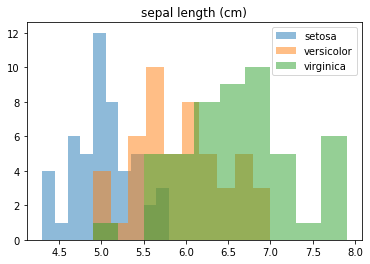

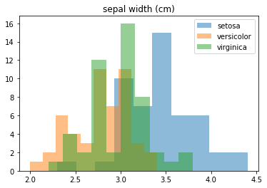

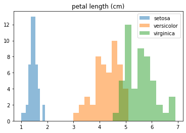

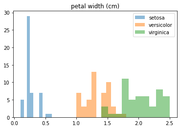

```python
# a histogram for each feature (outer loop);
# make a separate histogram for each species (inner loop).
# At the end of the inner loop, plt.show() finishes the current plot (s.t. later hists are placed into a new plot).
# We use alpha=0.5 to make it possible to distinguish the species.

for colname in df.columns[:4]:
    for species in df["species"].unique():
        idx = df["species"]==species
        plt.hist ( df[idx].loc[:,colname], alpha=0.5, label=species )
    plt.title(colname)
    plt.legend()
    plt.show()
```

```python
np.linspace(3,5,20)
```

```
array([3.        , 3.10526316, 3.21052632, 3.31578947, 3.42105263,
       3.52631579, 3.63157895, 3.73684211, 3.84210526, 3.94736842,
       4.05263158, 4.15789474, 4.26315789, 4.36842105, 4.47368421,
       4.57894737, 4.68421053, 4.78947368, 4.89473684, 5.        ])
```

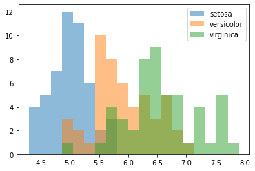

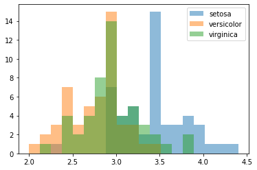

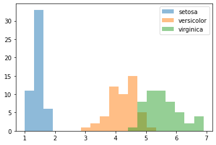

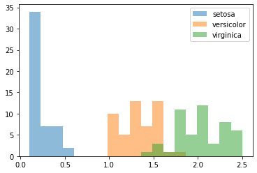

```python
# note that the bin widths are not comparable in the histograms.
# (Especially in the last plot).
# it is a good practice to use common bins whenever different histograms
# are plotted in the same window.

for colname in df.columns[:4]:
    value_min = df.loc[:,colname].min()
    value_max = df.loc[:,colname].max()
    bins = np.linspace(value_min,value_max,20)

    for species in df["species"].unique():
        idx = df["species"]==species
        plt.hist ( df[idx].loc[:,colname], alpha=0.5, label=species, bins=bins )
    plt.legend()
    plt.show()
```

```python
# We could try out different number of bins. What would you expect if we write
#
# bins = np.linspace(value_min,value_max,5)
#
# or
#
# bins = np.linspace(value_min,value_max,50)
#
# ?
```

- ALTERNATIVELY: Histograms via pandas groupby mechanism

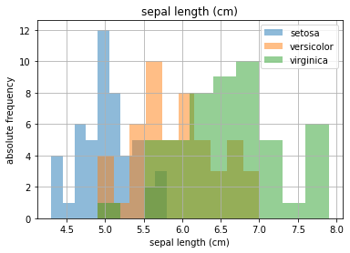

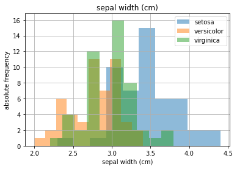

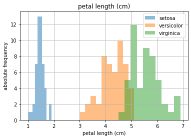

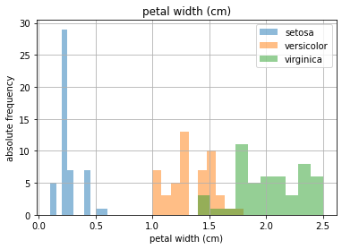

```python
for colname in df.columns[:4]:
    df.groupby("species")[colname].hist(alpha=0.5, legend=True)
    plt.title(colname)
    plt.xlabel(colname)
    plt.ylabel("absolute frequency")
    plt.show()
```

```python
# How would you implement to use the same bins for each species?
```

- Scatterplots

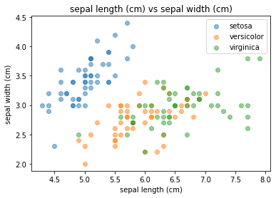

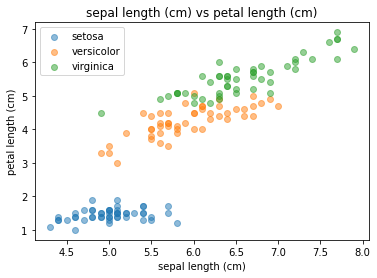

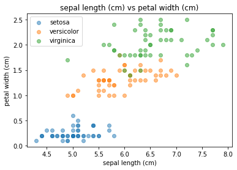

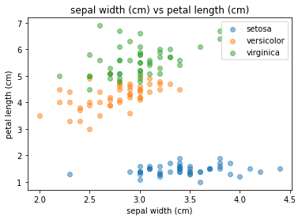

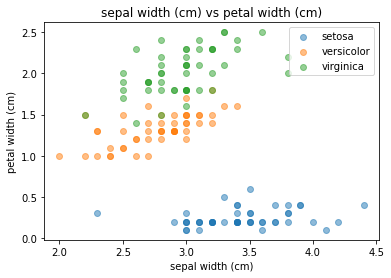

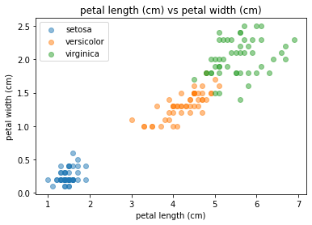

```python
# in the outer loop(s), we loop over all pairs of columns for which we want to create a scatterplot.
# Again, in the inner loop, we plot the different species.
#
# The usage of enumerate in the outer loops is a common construction to get all ordered pairs, i.e. to avoid
# (2,1) if (1,2) has already been plotted.

# for i,c1 in enumerate(df.columns[:4]):
#     for j,c2 in enumerate(df.columns[:4]):
#         if i >= j: continue

for i,c1 in enumerate(df.columns[:4]):
    for j,c2 in enumerate(df.columns[:4]):
        if i >= j: continue

        for species in df["species"].unique():
            idx = df["species"]==species
            plt.scatter ( df[idx].loc[:,c1], df[idx].loc[:,c2], alpha=0.5, label=species )

        plt.xlabel(c1)
        plt.ylabel(c2)
        plt.title("{0} vs {1}".format(c1,c2))
        plt.legend()
        plt.show()
```

- ALTERNATIVELY: use the seaborn library

https://seaborn.pydata.org/generated/seaborn.pairplot.html

https://seaborn.pydata.org/generated/seaborn.jointplot.html

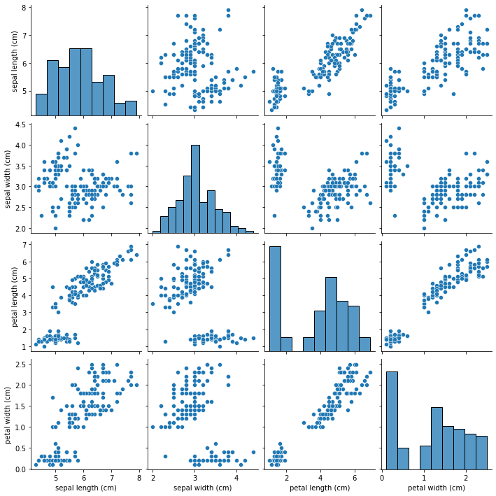

```python
import seaborn as sns

# by default, the plots on the diagonal are histograms, if the parameter "hue" is not used
sns.pairplot(df.iloc[:,:4])
```

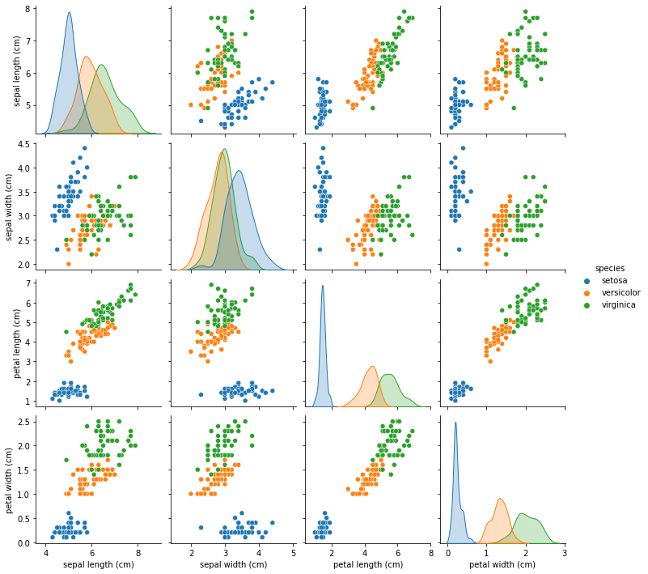

```python
# by default, the plots on the diagonal are kernel density estimates, if the parameter "hue" is used
sns.pairplot(df, hue="species")
```

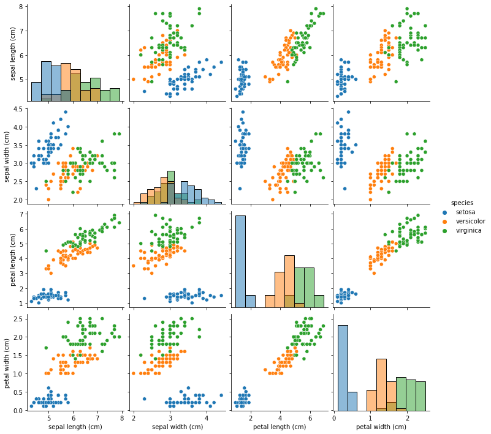

```python
# we can enforce the usage of histograms
# ==> take-home-message: always have a look at the documentation when using a high-level api like seaborn
sns.pairplot(df, hue="species", diag_kind="hist")
```